# citationsr

# 1 citationsr

The R package `citationsr` comprises functions that can be used to extract and analyze citation cases. When study A cites study B, it contains text fragments that refer to study B. We call study A a *citing document* and the text fragments it contains *citation cases*.

This readme serves to outline the methods applied in [Bauer et al. (2016)](http://dx.doi.org/10.2139/ssrn.2874549) with contributions from [Paul C. Bauer](http://www.paulcbauer.eu/), [Pablo Barberà](http://pablobarbera.com/) and [Simon Munzert](http://simonmunzert.github.io/). The idea is to go beyond a simple and primitive analysis of impact as ‘times cited’. The code is licensed under an [Attribution-NonCommercial-ShareAlike 4.0 International (CC BY-NC-SA 4.0)](https://creativecommons.org/licenses/by-nc-sa/4.0/) license.

**Disclaimer**: We currently don’t have time to work on this project and **can’t provide support**. But we hope to develop it further at a later stage.

If you have questions please contact us at mail@paulcbauer.eu.

# 2 Intro & setup

## 2.1 Background

We are interested in questions such as the following:

- *What do others write about a particular study? Which studies engage seriously with a particular study?*

The tutorial illustrates how the code in the package `citationsr` can be used to investigate the impact of a particular study. The tutorial targets users that are very familiar with R. In principle, one may want to analyze the impact of a single or several studies. Most steps are common to both aims.

As described more extensively in [Bauer et al. (2016)](http://dx.doi.org/10.2139/ssrn.2874549) we need to pursue the following steps:

1. **Collect citation information, i.e. which works cite our study(ies) of interest**
   - Documents that cite a study are called *citing documents*, text passages within those documents that refer to a study are called *citation cases*.
2. **Collect the full text of citing documents**
3. **Convert citing documents into raw text that can be analyzed**
4. **Collect metadata on the citing documents**
5. **Extract citation cases from citing documents**
6. **Analyze citation cases**

Below we present code that cycles through those steps. Essentially, we present the steps pursued in our study in which we investigate the impact of six highly cited studies in the fields of Political Science, Sociology and Economics.

Importantly, all of the above steps require methods that come with error. For intance Step 2, collecting fulltexts, contains error because we are not able to collect all fulltexts. Step 5, extracting citation cases, contains error because technically it is a challenging problem. Hence, the methods we present here are by no means perfect.

## 2.2 Package installation

Right now you can install the package from github for which you need to install the `devtools` package.

```r
install.packages("devtools")
library(devtools)
install_github("paulcbauer/citationsr")
```

## 2.3 Create working directory + subfolder

Create a working directory in which you store all the files linked to the analysis. We created a folder called `analysis` within which most of the analysis will take place.

# 3 Collect citation information/citations

In principle there are several ways to do this. Here we just present one approach relying on the Web of Science. Naturally, the citation information from the Web of Science is biased in various ways, e.g. it mostly contains journal publications and not books.

## 3.1 Web of Science

It is rather easy to program an R function that scrapes websites such as the Web of Science. However, since that is not legal, we present the manual way here. The Web of Science lets you download 500 citation records at a time and you can obtain them following the steps below. Unfortunately, you need access to the Web of Science (usually trough your university).

- Search for the study of interest

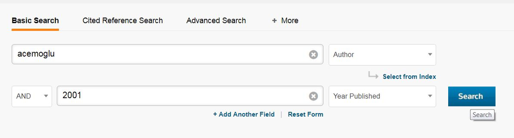

- Identify the right study in the list and click on ‘Times Cited’

[figure not shown]

- Save citation records “Other File Formats”

[figure not shown]

- Choose number of records (max. 500), record content (‘Author, Title, Source’) and File Format (‘Tab-delimited’) and click send.

[figure not shown]

- Change name of downloaded file with author names, year and pages of exported records and copy the files to the `analysis/citations` folder.

[figure not shown]

[figure not shown]

- Your `analysis/citations` folder should like below.

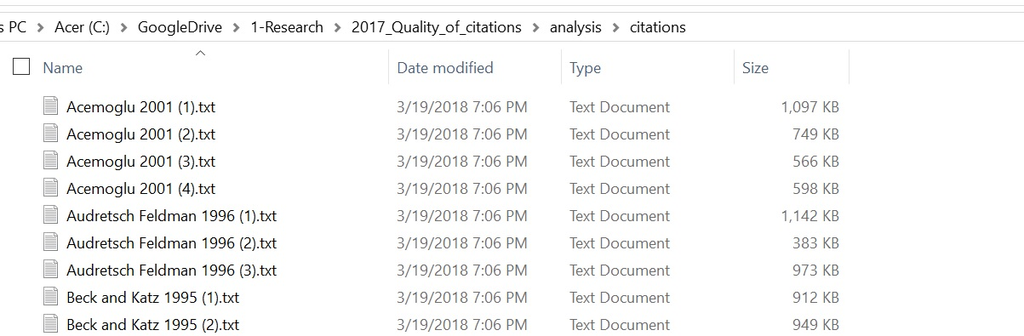

# 4 Collect fulltexts of citing documents

Again there are several ways to do this. We’ll go with the third approach.

1. Manual approach: Click & Save on Google Scholar
2. Automated approach: Fulltext package
3. Automated approach: Paperpile

## 4.1 Manual approach: Click & Save on Google Scholar

Go to GoogleScholar. Search for you article of interest. Click on `cited by`. Go through the articles and download those that you can access through the links on the right. Potentially, you will get more articles then by going through the citations that you get from the web of knowledge. On the other hand it’s increadibly laborious.

## 4.2 Automated approach: Fulltext package

The `fulltext` package and the contained function `ft_get()` by Scott Chamberlain should be able to scrape fulltexts of articles if you feed it a set of dois.

## 4.3 Automated approach: Paperpile

Paperpile is a commercial reference manager (3 Euros/month for academics) that works together with Google Drive. The nice thing is that it includes a very PDF scraper (as other reference managers as well). Once you upload DOIs for the studies for which you want to collect fulltexts, paperpile does a good job at downloading them to your GoogleDrive.

To proceed we need two helper functions that are available in a package called paperpiler.

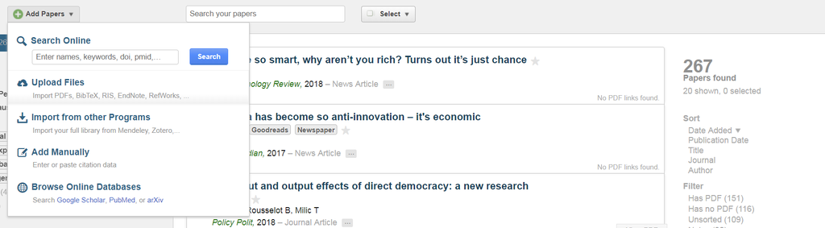

- Choose the “*.ris" files an click on “open”.

[figure not shown]

- Check “Organize into a new folder” and give a name to the folder, e.g. “impactanalysis”. Then click “Start upload”.

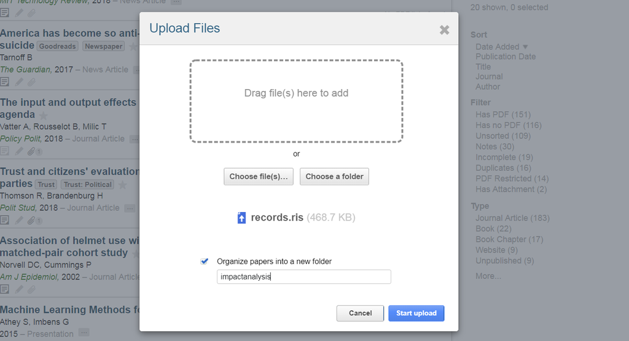

- Click on the folder “Impactanalysis” and click on the “Select” menu on “All”.

[figure not shown]

- In the “More actions…” menu click on “Auto-Update”.

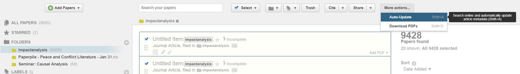

- Then you update auto-update so that paperpile fetches information on those articles using the DOIs. **Importantly, publishers dislike it when you download to many articles in one batch. Take this into account as you don’t want to block your university’s access to those publishers. Thus, download only small batches of PDFs and potentially discuss with your library before you do that or contact the publisher directly. Paperpile provides the following warning message**:

“*You are about to start an automatic bulk download of 9428 papers. If too many papers in your library are from a single publisher, your computer might get temporarily blocked from access to the publisher’s website. Also, if many of your papers have incomplete meta-data your computer might get blocked by Google Scholar because Paperpile make too many requests to find the missing data. Although temporary blocks are rare and not a big problem, please consider downloading the PDFs in smaller batches.*”

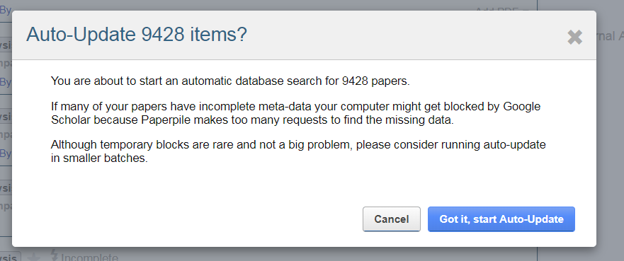

- Subsequently, you collect the PDFs which then sit in the paperpile folder on your computer. Click on the “More actions…” menu on “Download PDFs”.

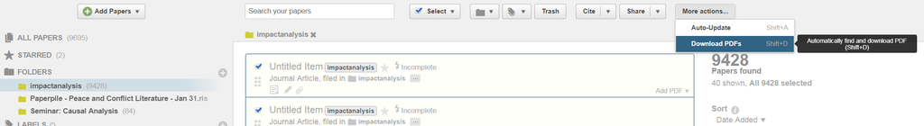